# Casal2 Test Case comparisons for HAK

# 1 HAK comparison of CASAL and Casal2 model configurations

This document compares the results of at least 2 CASAL model configurations (base and at least one sensitivity) and up to 8 Casal2 model configurations (3 BetaDiff, 2 CppAD, and 3 ADOL-C).

The CASAL model sensitivity 1 has a smaller tolerance value than the CASAL base model (1e-6 vs. 2e-3).

The Casal2 ADOL-C and BetaDiff low tolerance models have a smaller tolerance value than the CASAL base model (1e-6 vs. 2e-3). The Casal2 CppAD models have a tolerance value of 1e-9.

## 1.1 HAK model characteristics

The main characteristics of the Test Case HAK (hake) CASAL model are:

- one stock, ages 1 - 30
- one area
- years 1975 - 2018, projection years 2019 - 2022
- two time steps, duration 7 months and 5 months
- recruitment, spawning, aging, maturation, fishing in time step 1
- two stock categories: males and females, with user-provided maturity-at-age ogive
- natural mortality (M) of 0.19
- Beverton-Holt stock-recruitment relationship, with steepness (h) 0.8
- sex-specific Schnute age-length relationship
- sex-specific length-weight relationship ($W = aL^b$)
- ageing error type normal (c = 0.08)
- one fishery with logistic selectivity-at-age
- one survey with logistic selectivity-at-age

Observation data include:

- fishery CPUE index
- fishery proportions-at-age
- survey biomass index
- survey proportions-at-age

Parameters estimated include:

- B0
- catchability (q) for the fishery CPUE index and for the survey index
- fishery and survey selectivity parameters a50 and ato95
- YCS (recruitment deviations)

## 1.3 CASAL and Casal2 model output

```r
source('../../R-functions/report_read_in_CASAL_MPD_files.R')
```

```r
source('../../R-functions/report_read_in_Casal2_MPD_files.R')
```

## 1.4 Tables

Tables of parameter estimates and objective function components for the CASAL and Casal2 model MPD results

CASAL parameter estimates

| rownames | Base_Model | Sensitivity_1 | Percent_Diff |
| --- | --- | --- | --- |
| q[cpue].q | 0.00003 | 0.00003 | 0.039 |
| q[subaTANqA].q | 0.03771 | 0.03770 | 0.027 |
| initialization.B0 | 53970.00000 | 53970.00000 | 0.000 |
| relative_abundance[CPUE].cv_process_error | 0.18650 | 0.18650 | 0.000 |
| recruitment.YCS1 | 0.22040 | 0.22060 | -0.091 |
| recruitment.YCS2 | 0.25570 | 0.25540 | 0.117 |
| recruitment.YCS3 | 0.33280 | 0.33290 | -0.030 |
| recruitment.YCS4 | 0.52930 | 0.52920 | 0.019 |
| recruitment.YCS5 | 0.99350 | 0.99310 | 0.040 |
| recruitment.YCS6 | 0.45100 | 0.45120 | -0.044 |
| recruitment.YCS7 | 2.39200 | 2.39300 | -0.042 |
| recruitment.YCS8 | 0.26990 | 0.26920 | 0.259 |
| recruitment.YCS9 | 0.25710 | 0.25750 | -0.156 |
| recruitment.YCS10 | 0.39670 | 0.39660 | 0.025 |
| recruitment.YCS11 | 0.28060 | 0.28070 | -0.036 |
| recruitment.YCS12 | 0.18880 | 0.18880 | 0.000 |
| recruitment.YCS13 | 0.17060 | 0.17060 | 0.000 |
| recruitment.YCS14 | 0.22170 | 0.22180 | -0.045 |
| recruitment.YCS15 | 0.21300 | 0.21300 | 0.000 |
| recruitment.YCS16 | 0.26520 | 0.26520 | 0.000 |
| recruitment.YCS17 | 0.37740 | 0.37740 | 0.000 |
| recruitment.YCS18 | 0.42920 | 0.42930 | -0.023 |
| recruitment.YCS19 | 0.42380 | 0.42380 | 0.000 |
| recruitment.YCS20 | 0.33880 | 0.33880 | 0.000 |
| recruitment.YCS21 | 0.34650 | 0.34630 | 0.058 |
| recruitment.YCS22 | 0.40100 | 0.40100 | 0.000 |
| recruitment.YCS23 | 0.35060 | 0.35060 | 0.000 |
| recruitment.YCS24 | 0.34050 | 0.34050 | 0.000 |
| recruitment.YCS25 | 0.37130 | 0.37130 | 0.000 |
| recruitment.YCS26 | 0.30050 | 0.30060 | -0.033 |
| recruitment.YCS27 | 0.20100 | 0.20100 | 0.000 |
| recruitment.YCS28 | 0.21070 | 0.21070 | 0.000 |
| recruitment.YCS29 | 0.18550 | 0.18550 | 0.000 |
| recruitment.YCS30 | 0.23530 | 0.23530 | 0.000 |
| recruitment.YCS31 | 0.30040 | 0.30040 | 0.000 |
| recruitment.YCS32 | 0.33160 | 0.33160 | 0.000 |
| recruitment.YCS33 | 0.33130 | 0.33130 | 0.000 |
| recruitment.YCS34 | 0.27620 | 0.27620 | 0.000 |
| recruitment.YCS35 | 0.24600 | 0.24590 | 0.041 |
| recruitment.YCS36 | 0.23790 | 0.23790 | 0.000 |
| recruitment.YCS37 | 0.20490 | 0.20490 | 0.000 |
| recruitment.YCS38 | 0.19030 | 0.19040 | -0.053 |
| recruitment.YCS39 | 0.22450 | 0.22450 | 0.000 |
| recruitment.YCS40 | 0.17640 | 0.17630 | 0.057 |
| recruitment.YCS41 | 0.28110 | 0.28190 | -0.285 |
| recruitment.YCS42 | 0.32180 | 0.30430 | 5.438 |
| recruitment.YCS43 | 0.28430 | 0.30440 | -7.070 |
| recruitment.YCS44 | 1.00000 | 1.00000 | 0.000 |
| selectivity[subaTANselA].all1 | 3.05000 | 3.05000 | 0.000 |
| selectivity[subaTANselA].all2 | 0.14950 | 0.14960 | -0.067 |
| selectivity[subaFsel].all1 | 6.99500 | 6.99500 | 0.000 |
| selectivity[subaFsel].all2 | 2.70600 | 2.70700 | -0.037 |

Casal2 parameter estimates

| rownames | betadiff_casal_flags_on | betadiff_casal_flags_off | betadiff_casal_flags_on_low_tol | cppad_casal_flags_on | cppad_casal_flags_off | adolc_casal_flags_on | adolc_casal_flags_off | adolc_casal_flags_on_low_tol |
| --- | --- | --- | --- | --- | --- | --- | --- | --- |
| process[Recruitment].b0 | 53979.30000 | 53998.20000 | 53971.60000 | 53971.60000 | 53971.60000 | 53978.80000 | 53944.90000 | 53971.60000 |
| catchability[CPUEq].q | 0.00003 | 0.00003 | 0.00003 | 0.00003 | 0.00003 | 0.00003 | 0.00003 | 0.00003 |
| catchability[subaTANqA].q | 0.03770 | 0.03768 | 0.03770 | 0.03771 | 0.03771 | 0.03771 | 0.03772 | 0.03770 |
| selectivity[subaFsel].a50 | 6.99600 | 6.99588 | 6.99583 | 6.99584 | 6.99584 | 6.99598 | 6.99531 | 6.99583 |
| selectivity[subaFsel].ato95 | 2.70785 | 2.70814 | 2.70805 | 2.70805 | 2.70805 | 2.70877 | 2.70790 | 2.70805 |
| selectivity[subaTANselA].a50 | 3.03405 | 3.03659 | 3.03405 | 3.06310 | 3.06310 | 3.03416 | 3.03377 | 3.03415 |
| selectivity[subaTANselA].ato95 | 0.10105 | 0.10860 | 0.10107 | 0.18726 | 0.18726 | 0.10134 | 0.10023 | 0.10135 |
| observation[CPUE].process_error | 0.18650 | 0.18650 | 0.18649 | 0.18649 | 0.18649 | 0.18651 | 0.18652 | 0.18649 |
| process[Recruitment].ycs_values{1974} | 0.22062 | 0.22098 | 0.22060 | 0.22060 | 0.22060 | 0.22074 | 0.21782 | 0.22060 |
| process[Recruitment].ycs_values{1975} | 0.25548 | 0.25591 | 0.25534 | 0.25535 | 0.25535 | 0.25545 | 0.25419 | 0.25534 |
| process[Recruitment].ycs_values{1976} | 0.33339 | 0.33326 | 0.33312 | 0.33312 | 0.33312 | 0.33405 | 0.33180 | 0.33312 |
| process[Recruitment].ycs_values{1977} | 0.53445 | 0.53600 | 0.53131 | 0.53131 | 0.53131 | 0.53437 | 0.53060 | 0.53131 |
| process[Recruitment].ycs_values{1978} | 0.97876 | 0.98099 | 0.98817 | 0.98818 | 0.98818 | 0.98374 | 0.98075 | 0.98817 |
| process[Recruitment].ycs_values{1979} | 0.46087 | 0.45717 | 0.45379 | 0.45379 | 0.45379 | 0.45598 | 0.46143 | 0.45379 |
| process[Recruitment].ycs_values{1980} | 2.38696 | 2.38958 | 2.39155 | 2.39157 | 2.39157 | 2.39243 | 2.39128 | 2.39155 |
| process[Recruitment].ycs_values{1981} | 0.26893 | 0.26901 | 0.26921 | 0.26921 | 0.26921 | 0.26901 | 0.26888 | 0.26921 |
| process[Recruitment].ycs_values{1982} | 0.25781 | 0.25739 | 0.25749 | 0.25749 | 0.25749 | 0.25677 | 0.25913 | 0.25749 |
| process[Recruitment].ycs_values{1983} | 0.39547 | 0.39580 | 0.39605 | 0.39606 | 0.39606 | 0.39621 | 0.39427 | 0.39605 |
| process[Recruitment].ycs_values{1984} | 0.28093 | 0.28094 | 0.28098 | 0.28099 | 0.28099 | 0.28173 | 0.28226 | 0.28098 |
| process[Recruitment].ycs_values{1985} | 0.18860 | 0.18887 | 0.18870 | 0.18870 | 0.18870 | 0.18866 | 0.18784 | 0.18870 |
| process[Recruitment].ycs_values{1986} | 0.17043 | 0.17013 | 0.17051 | 0.17051 | 0.17051 | 0.17020 | 0.17102 | 0.17051 |
| process[Recruitment].ycs_values{1987} | 0.22154 | 0.22199 | 0.22180 | 0.22181 | 0.22181 | 0.22206 | 0.22193 | 0.22180 |
| process[Recruitment].ycs_values{1988} | 0.21302 | 0.21285 | 0.21291 | 0.21292 | 0.21292 | 0.21306 | 0.21206 | 0.21291 |
| process[Recruitment].ycs_values{1989} | 0.26487 | 0.26475 | 0.26515 | 0.26515 | 0.26515 | 0.26478 | 0.26676 | 0.26515 |
| process[Recruitment].ycs_values{1990} | 0.37693 | 0.37764 | 0.37722 | 0.37722 | 0.37722 | 0.37748 | 0.37506 | 0.37722 |
| process[Recruitment].ycs_values{1991} | 0.42923 | 0.42896 | 0.42968 | 0.42969 | 0.42969 | 0.42966 | 0.43135 | 0.42968 |
| process[Recruitment].ycs_values{1992} | 0.42309 | 0.42337 | 0.42336 | 0.42336 | 0.42336 | 0.42402 | 0.42359 | 0.42336 |
| process[Recruitment].ycs_values{1993} | 0.33892 | 0.33905 | 0.33895 | 0.33895 | 0.33895 | 0.33876 | 0.33621 | 0.33895 |
| process[Recruitment].ycs_values{1994} | 0.34571 | 0.34568 | 0.34626 | 0.34626 | 0.34626 | 0.34580 | 0.34937 | 0.34626 |
| process[Recruitment].ycs_values{1995} | 0.40093 | 0.40112 | 0.40086 | 0.40087 | 0.40087 | 0.40152 | 0.39871 | 0.40086 |
| process[Recruitment].ycs_values{1996} | 0.35017 | 0.35031 | 0.35062 | 0.35062 | 0.35062 | 0.35037 | 0.35139 | 0.35062 |
| process[Recruitment].ycs_values{1997} | 0.34023 | 0.34036 | 0.34043 | 0.34044 | 0.34044 | 0.34064 | 0.34018 | 0.34043 |
| process[Recruitment].ycs_values{1998} | 0.37100 | 0.37109 | 0.37119 | 0.37119 | 0.37119 | 0.37126 | 0.37127 | 0.37119 |
| process[Recruitment].ycs_values{1999} | 0.30017 | 0.30039 | 0.30049 | 0.30049 | 0.30049 | 0.30056 | 0.30039 | 0.30049 |
| process[Recruitment].ycs_values{2000} | 0.20099 | 0.20093 | 0.20099 | 0.20099 | 0.20099 | 0.20101 | 0.20095 | 0.20099 |
| process[Recruitment].ycs_values{2001} | 0.21042 | 0.21065 | 0.21069 | 0.21069 | 0.21069 | 0.21087 | 0.21074 | 0.21069 |
| process[Recruitment].ycs_values{2002} | 0.18544 | 0.18541 | 0.18547 | 0.18548 | 0.18548 | 0.18539 | 0.18530 | 0.18547 |
| process[Recruitment].ycs_values{2003} | 0.23505 | 0.23520 | 0.23524 | 0.23524 | 0.23524 | 0.23542 | 0.23530 | 0.23524 |
| process[Recruitment].ycs_values{2004} | 0.30016 | 0.30031 | 0.30036 | 0.30036 | 0.30036 | 0.30043 | 0.30022 | 0.30036 |
| process[Recruitment].ycs_values{2005} | 0.33138 | 0.33148 | 0.33155 | 0.33155 | 0.33155 | 0.33163 | 0.33151 | 0.33155 |
| process[Recruitment].ycs_values{2006} | 0.33100 | 0.33126 | 0.33128 | 0.33129 | 0.33129 | 0.33150 | 0.33121 | 0.33128 |
| process[Recruitment].ycs_values{2007} | 0.27602 | 0.27606 | 0.27611 | 0.27612 | 0.27612 | 0.27615 | 0.27599 | 0.27611 |
| process[Recruitment].ycs_values{2008} | 0.24575 | 0.24590 | 0.24593 | 0.24593 | 0.24593 | 0.24602 | 0.24589 | 0.24593 |
| process[Recruitment].ycs_values{2009} | 0.23781 | 0.23789 | 0.23792 | 0.23792 | 0.23792 | 0.23797 | 0.23786 | 0.23792 |
| process[Recruitment].ycs_values{2010} | 0.20479 | 0.20478 | 0.20479 | 0.20479 | 0.20479 | 0.20486 | 0.20466 | 0.20479 |
| process[Recruitment].ycs_values{2011} | 0.19029 | 0.19038 | 0.19039 | 0.19039 | 0.19039 | 0.19062 | 0.19063 | 0.19039 |
| process[Recruitment].ycs_values{2012} | 0.22446 | 0.22470 | 0.22452 | 0.22452 | 0.22452 | 0.22472 | 0.22407 | 0.22452 |
| process[Recruitment].ycs_values{2013} | 0.17605 | 0.17602 | 0.17625 | 0.17625 | 0.17625 | 0.17639 | 0.17699 | 0.17625 |
| process[Recruitment].ycs_values{2014} | 0.28034 | 0.27972 | 0.28185 | 0.28186 | 0.28186 | 0.28120 | 0.28195 | 0.28185 |
| process[Recruitment].ycs_values{2015} | 0.32757 | 0.32888 | 0.30425 | 0.30425 | 0.30425 | 0.33106 | 0.32867 | 0.30425 |
| process[Recruitment].ycs_values{2016} | 0.28104 | 0.27971 | 0.30437 | 0.30437 | 0.30437 | 0.27836 | 0.27991 | 0.30437 |

Casal2 parameter estimates: Percent Difference from betadiff_casal_flags_on

| rownames | betadiff_casal_flags_on | betadiff_casal_flags_off | betadiff_casal_flags_on_low_tol | cppad_casal_flags_on | cppad_casal_flags_off | adolc_casal_flags_on | adolc_casal_flags_off | adolc_casal_flags_on_low_tol |
| --- | --- | --- | --- | --- | --- | --- | --- | --- |
| process[Recruitment].b0 | 0.000 | -0.035 | 0.014 | 0.014 | 0.014 | 0.001 | 0.064 | 0.014 |
| catchability[CPUEq].q | 0.000 | 0.041 | -0.013 | -0.013 | -0.013 | -0.011 | -0.041 | -0.013 |
| catchability[subaTANqA].q | 0.000 | 0.044 | -0.021 | -0.021 | -0.021 | -0.022 | -0.053 | -0.021 |
| selectivity[subaFsel].a50 | 0.000 | 0.002 | 0.002 | 0.002 | 0.002 | 0.000 | 0.010 | 0.002 |
| selectivity[subaFsel].ato95 | 0.000 | -0.011 | -0.007 | -0.007 | -0.007 | -0.034 | -0.002 | -0.007 |
| selectivity[subaTANselA].a50 | 0.000 | -0.084 | 0.000 | -0.957 | -0.957 | -0.004 | 0.009 | -0.003 |
| selectivity[subaTANselA].ato95 | 0.000 | -7.472 | -0.021 | -85.325 | -85.325 | -0.295 | 0.811 | -0.300 |
| observation[CPUE].process_error | 0.000 | 0.000 | 0.009 | 0.009 | 0.009 | -0.003 | -0.011 | 0.009 |
| process[Recruitment].ycs_values{1974} | 0.000 | -0.163 | 0.011 | 0.010 | 0.010 | -0.055 | 1.269 | 0.011 |
| process[Recruitment].ycs_values{1975} | 0.000 | -0.167 | 0.054 | 0.053 | 0.053 | 0.014 | 0.506 | 0.054 |
| process[Recruitment].ycs_values{1976} | 0.000 | 0.039 | 0.081 | 0.080 | 0.080 | -0.198 | 0.478 | 0.081 |
| process[Recruitment].ycs_values{1977} | 0.000 | -0.289 | 0.588 | 0.588 | 0.588 | 0.015 | 0.721 | 0.588 |
| process[Recruitment].ycs_values{1978} | 0.000 | -0.228 | -0.962 | -0.962 | -0.962 | -0.509 | -0.203 | -0.962 |
| process[Recruitment].ycs_values{1979} | 0.000 | 0.803 | 1.537 | 1.536 | 1.536 | 1.061 | -0.122 | 1.537 |
| process[Recruitment].ycs_values{1980} | 0.000 | -0.110 | -0.192 | -0.193 | -0.193 | -0.229 | -0.181 | -0.192 |
| process[Recruitment].ycs_values{1981} | 0.000 | -0.030 | -0.104 | -0.104 | -0.104 | -0.030 | 0.019 | -0.104 |
| process[Recruitment].ycs_values{1982} | 0.000 | 0.161 | 0.124 | 0.123 | 0.123 | 0.401 | -0.512 | 0.124 |
| process[Recruitment].ycs_values{1983} | 0.000 | -0.084 | -0.147 | -0.148 | -0.148 | -0.187 | 0.303 | -0.147 |
| process[Recruitment].ycs_values{1984} | 0.000 | -0.006 | -0.020 | -0.021 | -0.021 | -0.286 | -0.474 | -0.020 |
| process[Recruitment].ycs_values{1985} | 0.000 | -0.141 | -0.052 | -0.053 | -0.053 | -0.027 | 0.407 | -0.052 |
| process[Recruitment].ycs_values{1986} | 0.000 | 0.177 | -0.045 | -0.046 | -0.046 | 0.134 | -0.341 | -0.045 |
| process[Recruitment].ycs_values{1987} | 0.000 | -0.204 | -0.121 | -0.122 | -0.122 | -0.236 | -0.176 | -0.121 |
| process[Recruitment].ycs_values{1988} | 0.000 | 0.077 | 0.048 | 0.048 | 0.048 | -0.019 | 0.447 | 0.048 |
| process[Recruitment].ycs_values{1989} | 0.000 | 0.045 | -0.103 | -0.103 | -0.103 | 0.036 | -0.711 | -0.103 |
| process[Recruitment].ycs_values{1990} | 0.000 | -0.188 | -0.076 | -0.076 | -0.076 | -0.146 | 0.496 | -0.076 |
| process[Recruitment].ycs_values{1991} | 0.000 | 0.062 | -0.106 | -0.107 | -0.107 | -0.101 | -0.494 | -0.106 |
| process[Recruitment].ycs_values{1992} | 0.000 | -0.066 | -0.064 | -0.065 | -0.065 | -0.221 | -0.120 | -0.064 |
| process[Recruitment].ycs_values{1993} | 0.000 | -0.037 | -0.008 | -0.009 | -0.009 | 0.049 | 0.801 | -0.008 |
| process[Recruitment].ycs_values{1994} | 0.000 | 0.009 | -0.159 | -0.159 | -0.159 | -0.026 | -1.059 | -0.159 |
| process[Recruitment].ycs_values{1995} | 0.000 | -0.047 | 0.017 | 0.016 | 0.016 | -0.146 | 0.554 | 0.017 |
| process[Recruitment].ycs_values{1996} | 0.000 | -0.041 | -0.127 | -0.128 | -0.128 | -0.057 | -0.348 | -0.127 |
| process[Recruitment].ycs_values{1997} | 0.000 | -0.038 | -0.059 | -0.060 | -0.060 | -0.121 | 0.015 | -0.059 |
| process[Recruitment].ycs_values{1998} | 0.000 | -0.024 | -0.050 | -0.051 | -0.051 | -0.068 | -0.072 | -0.050 |
| process[Recruitment].ycs_values{1999} | 0.000 | -0.072 | -0.105 | -0.106 | -0.106 | -0.130 | -0.071 | -0.105 |
| process[Recruitment].ycs_values{2000} | 0.000 | 0.030 | -0.000 | -0.001 | -0.001 | -0.009 | 0.023 | -0.000 |
| process[Recruitment].ycs_values{2001} | 0.000 | -0.109 | -0.125 | -0.126 | -0.126 | -0.211 | -0.149 | -0.125 |
| process[Recruitment].ycs_values{2002} | 0.000 | 0.015 | -0.019 | -0.019 | -0.019 | 0.026 | 0.074 | -0.019 |
| process[Recruitment].ycs_values{2003} | 0.000 | -0.062 | -0.079 | -0.080 | -0.080 | -0.154 | -0.107 | -0.079 |
| process[Recruitment].ycs_values{2004} | 0.000 | -0.049 | -0.068 | -0.068 | -0.068 | -0.091 | -0.019 | -0.068 |
| process[Recruitment].ycs_values{2005} | 0.000 | -0.030 | -0.052 | -0.053 | -0.053 | -0.075 | -0.041 | -0.052 |
| process[Recruitment].ycs_values{2006} | 0.000 | -0.079 | -0.086 | -0.087 | -0.087 | -0.152 | -0.063 | -0.086 |
| process[Recruitment].ycs_values{2007} | 0.000 | -0.014 | -0.034 | -0.034 | -0.034 | -0.046 | 0.010 | -0.034 |
| process[Recruitment].ycs_values{2008} | 0.000 | -0.064 | -0.074 | -0.074 | -0.074 | -0.113 | -0.057 | -0.074 |
| process[Recruitment].ycs_values{2009} | 0.000 | -0.034 | -0.047 | -0.048 | -0.048 | -0.066 | -0.021 | -0.047 |
| process[Recruitment].ycs_values{2010} | 0.000 | 0.004 | 0.002 | 0.001 | 0.001 | -0.031 | 0.063 | 0.002 |
| process[Recruitment].ycs_values{2011} | 0.000 | -0.047 | -0.055 | -0.056 | -0.056 | -0.173 | -0.180 | -0.055 |
| process[Recruitment].ycs_values{2012} | 0.000 | -0.105 | -0.025 | -0.026 | -0.026 | -0.114 | 0.172 | -0.025 |
| process[Recruitment].ycs_values{2013} | 0.000 | 0.012 | -0.116 | -0.117 | -0.117 | -0.197 | -0.535 | -0.116 |
| process[Recruitment].ycs_values{2014} | 0.000 | 0.224 | -0.539 | -0.540 | -0.540 | -0.307 | -0.575 | -0.539 |
| process[Recruitment].ycs_values{2015} | 0.000 | -0.399 | 7.119 | 7.118 | 7.118 | -1.064 | -0.336 | 7.119 |
| process[Recruitment].ycs_values{2016} | 0.000 | 0.473 | -8.301 | -8.301 | -8.301 | 0.955 | 0.403 | -8.300 |

CASAL objective function component values

| Component | Base_Model | Sensitivity_1 |
| --- | --- | --- |
| CPUE | -30.370 | -30.370 |
| subaTANbiomassDEC | -15.230 | -15.230 |
| subaTANageDEC | 388.900 | 388.900 |
| subaOBSage | 397.100 | 397.100 |
| prior_on_q[cpue].q | -10.580 | -10.580 |
| prior_on_q[subaTANqA].q | -1.786 | -1.786 |
| prior_on_initialization.B0 | 10.900 | 10.900 |
| prior_on_relative_abundance[CPUE].cv_process_error | -1.679 | -1.679 |
| prior_on_recruitment.YCS | -28.220 | -28.230 |
| prior_on_selectivity[subaTANselA].all | 0.000 | 0.000 |
| prior_on_selectivity[subaFsel].all | 0.000 | 0.000 |
| subaCatchMustBeTaken | 0.000 | 0.000 |
| Total | 709.100 | 709.100 |

Casal2 objective function component values

| rownames | betadiff_casal_flags_on | betadiff_casal_flags_off | betadiff_casal_flags_on_low_tol | cppad_casal_flags_on | cppad_casal_flags_off | adolc_casal_flags_on | adolc_casal_flags_off | adolc_casal_flags_on_low_tol |
| --- | --- | --- | --- | --- | --- | --- | --- | --- |
| observation->subaTANbiomassDEC-1992 | 0.431 | 0.431 | 0.431 | 0.431 | 0.431 | 0.430 | 0.431 | 0.431 |
| observation->subaTANbiomassDEC-1993 | -0.287 | -0.287 | -0.286 | -0.286 | -0.286 | -0.286 | -0.286 | -0.286 |
| observation->subaTANbiomassDEC-1994 | -1.466 | -1.466 | -1.466 | -1.466 | -1.466 | -1.466 | -1.466 | -1.466 |
| observation->subaTANbiomassDEC-2001 | -1.139 | -1.138 | -1.139 | -1.139 | -1.139 | -1.139 | -1.139 | -1.139 |
| observation->subaTANbiomassDEC-2002 | -1.282 | -1.282 | -1.282 | -1.282 | -1.282 | -1.282 | -1.282 | -1.282 |
| observation->subaTANbiomassDEC-2003 | -1.110 | -1.111 | -1.110 | -1.110 | -1.110 | -1.110 | -1.110 | -1.110 |
| observation->subaTANbiomassDEC-2004 | -1.034 | -1.034 | -1.034 | -1.034 | -1.034 | -1.034 | -1.034 | -1.034 |
| observation->subaTANbiomassDEC-2005 | -1.190 | -1.190 | -1.190 | -1.190 | -1.190 | -1.190 | -1.190 | -1.190 |
| observation->subaTANbiomassDEC-2006 | -1.058 | -1.058 | -1.058 | -1.058 | -1.058 | -1.058 | -1.058 | -1.058 |
| observation->subaTANbiomassDEC-2007 | -1.269 | -1.269 | -1.269 | -1.269 | -1.269 | -1.269 | -1.269 | -1.269 |
| observation->subaTANbiomassDEC-2008 | -0.159 | -0.158 | -0.159 | -0.159 | -0.159 | -0.159 | -0.159 | -0.159 |
| observation->subaTANbiomassDEC-2009 | -0.807 | -0.806 | -0.807 | -0.807 | -0.807 | -0.807 | -0.807 | -0.807 |
| observation->subaTANbiomassDEC-2010 | -1.179 | -1.179 | -1.178 | -1.178 | -1.178 | -1.178 | -1.178 | -1.178 |
| observation->subaTANbiomassDEC-2012 | -0.948 | -0.948 | -0.948 | -0.948 | -0.948 | -0.948 | -0.948 | -0.948 |
| observation->subaTANbiomassDEC-2013 | -0.936 | -0.936 | -0.936 | -0.936 | -0.936 | -0.936 | -0.936 | -0.936 |
| observation->subaTANbiomassDEC-2015 | -1.163 | -1.163 | -1.163 | -1.163 | -1.163 | -1.163 | -1.163 | -1.163 |
| observation->subaTANbiomassDEC-2017 | -0.635 | -0.635 | -0.635 | -0.635 | -0.635 | -0.635 | -0.635 | -0.635 |
| observation->subaTANageDEC-1990 | 16.569 | 16.566 | 16.566 | 16.566 | 16.566 | 16.566 | 16.574 | 16.566 |
| observation->subaTANageDEC-1992 | 19.098 | 19.097 | 19.096 | 19.096 | 19.096 | 19.097 | 19.092 | 19.096 |
| observation->subaTANageDEC-1993 | 22.352 | 22.352 | 22.351 | 22.351 | 22.351 | 22.346 | 22.351 | 22.351 |
| observation->subaTANageDEC-1994 | 27.486 | 27.485 | 27.486 | 27.486 | 27.486 | 27.484 | 27.485 | 27.486 |
| observation->subaTANageDEC-2001 | 25.959 | 25.957 | 25.958 | 25.958 | 25.958 | 25.958 | 25.951 | 25.958 |
| observation->subaTANageDEC-2002 | 26.344 | 26.344 | 26.346 | 26.346 | 26.346 | 26.346 | 26.347 | 26.346 |
| observation->subaTANageDEC-2003 | 25.674 | 25.672 | 25.672 | 25.672 | 25.672 | 25.673 | 25.672 | 25.672 |
| observation->subaTANageDEC-2004 | 19.469 | 19.470 | 19.469 | 19.469 | 19.469 | 19.470 | 19.469 | 19.469 |
| observation->subaTANageDEC-2005 | 19.258 | 19.258 | 19.259 | 19.259 | 19.259 | 19.258 | 19.260 | 19.259 |
| observation->subaTANageDEC-2006 | 20.374 | 20.374 | 20.373 | 20.373 | 20.373 | 20.373 | 20.371 | 20.373 |
| observation->subaTANageDEC-2007 | 24.452 | 24.452 | 24.452 | 24.452 | 24.452 | 24.453 | 24.452 | 24.452 |
| observation->subaTANageDEC-2008 | 23.587 | 23.587 | 23.587 | 23.587 | 23.587 | 23.587 | 23.586 | 23.587 |
| observation->subaTANageDEC-2009 | 24.427 | 24.426 | 24.427 | 24.427 | 24.427 | 24.426 | 24.427 | 24.427 |

[output cut: 108 more lines]

```
## [1] "CASAL base model convergence information"
## [1] "fmm: have converged: t = 0.000763901 f = 709.088"
## [2] "Successful convergence in optimise"
## [3] "Minimiser achieved convergence after 216 quasi-Newton iterations using 262 objective function evaluations"
## [1] ""
## [1] "CASAL sensitivity 1 model convergence information"
## [1] "Minimiser convergence threshold: 1e-06"
## [2] "fmm: have converged: t = 7.73884e-07 f = 709.083"
## [3] "Successful convergence in optimise"
## [4] "Minimiser achieved convergence after 234 quasi-Newton iterations using 280 objective function evaluations"
## [1] ""
## [1] "Casal2 betadiff_casal_flags_on model convergence information"
## [1] "fmm: have converged: t = 0.00170442 f = 709.021"
## [2] "Successful convergence in optimise"
## [1] ""
```

[output cut: 44 more lines]

```
## [1] "CASAL model warnings"
##                         parameter  estimate lower.bound upper.bound
## 1                       q[cpue].q 2.535e-05       1e-08         0.1
## 2 selectivity[subaTANselA].all[2]    0.1495         0.1          50
## [1] ""
## [1] "CASAL sensitivity 1 model warnings"
##                         parameter  estimate lower.bound upper.bound
## 1                       q[cpue].q 2.534e-05       1e-08         0.1
## 2 selectivity[subaTANselA].all[2]    0.1496         0.1          50
## [1] ""
## [1] "Casal2 betadiff_casal_flags_on model warnings"
## $warnings_found
## [1] 2
##
## $warning_0
## [1] "Estimates were removed because of matching lower and upper bounds. Originally had 52 estimates, now have 51"
##
## $warning_1
## [1] "estimated parameter 'catchability[CPUEq].q' was within 0.001 of lower bound 1e-08"
##
## $type
## [1] "warnings"
##
## [1] ""
## [1] "Casal2 betadiff_casal_flags_off model warnings"
## $warnings_found
## [1] 2
##
## $warning_0
## [1] "Estimates were removed because of matching lower and upper bounds. Originally had 52 estimates, now have 51"
##
## $warning_1
## [1] "estimated parameter 'catchability[CPUEq].q' was within 0.001 of lower bound 1e-08"
##
## $type
## [1] "warnings"
##
## [1] ""
## [1] "Casal2 betadiff_casal_flags_on_low_tol model warnings"
## $warnings_found
```

[output cut: 68 more lines]

```
## [1] "warnings"
##
## [1] ""
## [1] "Casal2 adolc_casal_flags_on_low_tol model warnings"
## $warnings_found
## [1] 2
##
## $warning_0
## [1] "Estimates were removed because of matching lower and upper bounds. Originally had 52 estimates, now have 51"
##
## $warning_1
## [1] "estimated parameter 'catchability[CPUEq].q' was within 0.001 of lower bound 1e-08"
##
## $type
## [1] "warnings"
```

## 1.5 Matching of outputs

Time series comparisons with CASAL base model results

```
## [1] "Catch time series base model comparison for run betadiff_casal_flags_on"
## [1] "Actual catches for fishery match: yes"
## [1] ""
## [1] "Catch time series base model comparison for run betadiff_casal_flags_off"
## [1] "Actual catches for fishery match: yes"
## [1] ""
## [1] "Catch time series base model comparison for run betadiff_casal_flags_on_low_tol"
## [1] "Actual catches for fishery match: yes"
## [1] ""
## [1] "Catch time series base model comparison for run cppad_casal_flags_on"
## [1] "Actual catches for fishery match: yes"
## [1] ""
## [1] "Catch time series base model comparison for run cppad_casal_flags_off"
## [1] "Actual catches for fishery match: yes"
## [1] ""
## [1] "Catch time series base model comparison for run adolc_casal_flags_on"
## [1] "Actual catches for fishery match: yes"
## [1] ""
## [1] "Catch time series base model comparison for run adolc_casal_flags_off"
## [1] "Actual catches for fishery match: yes"
## [1] ""
## [1] "Catch time series base model comparison for run adolc_casal_flags_on_low_tol"
## [1] "Actual catches for fishery match: yes"
## [1] ""
```

Derived quantities

## 1.6 Plots

Comparison plots

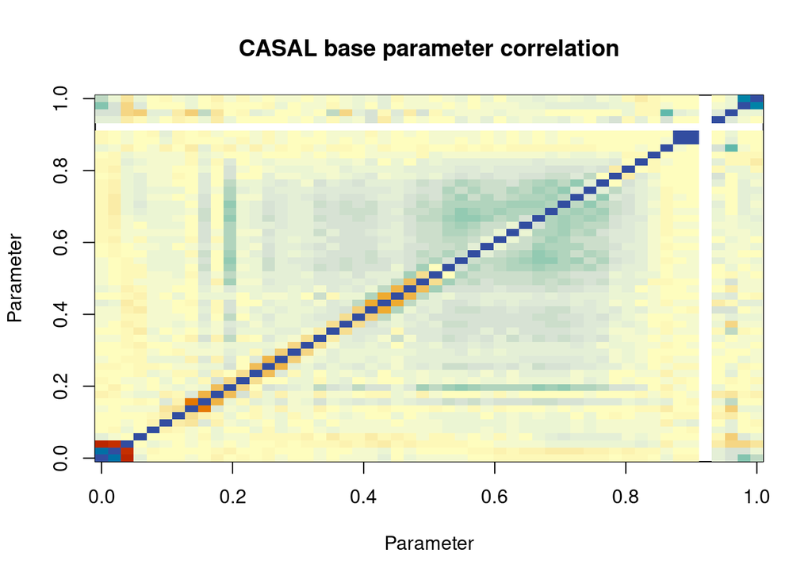

```
## [1] "CASAL base parameter correlation range (excluding 1.0): -0.9211 0.9883"
```

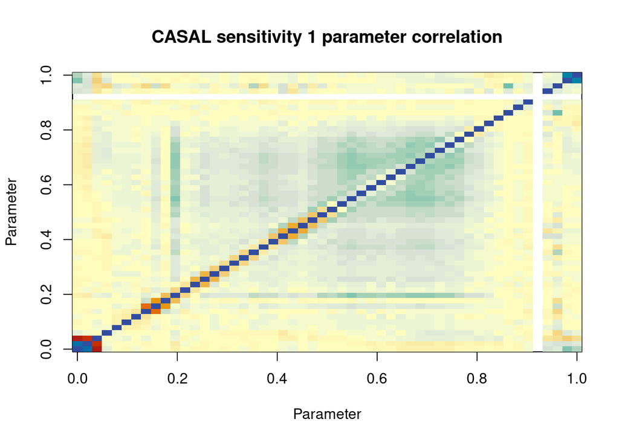

```
## [1] "CASAL sensitivity 1 parameter correlation range (excluding 1.0): -0.9225 0.845"
```

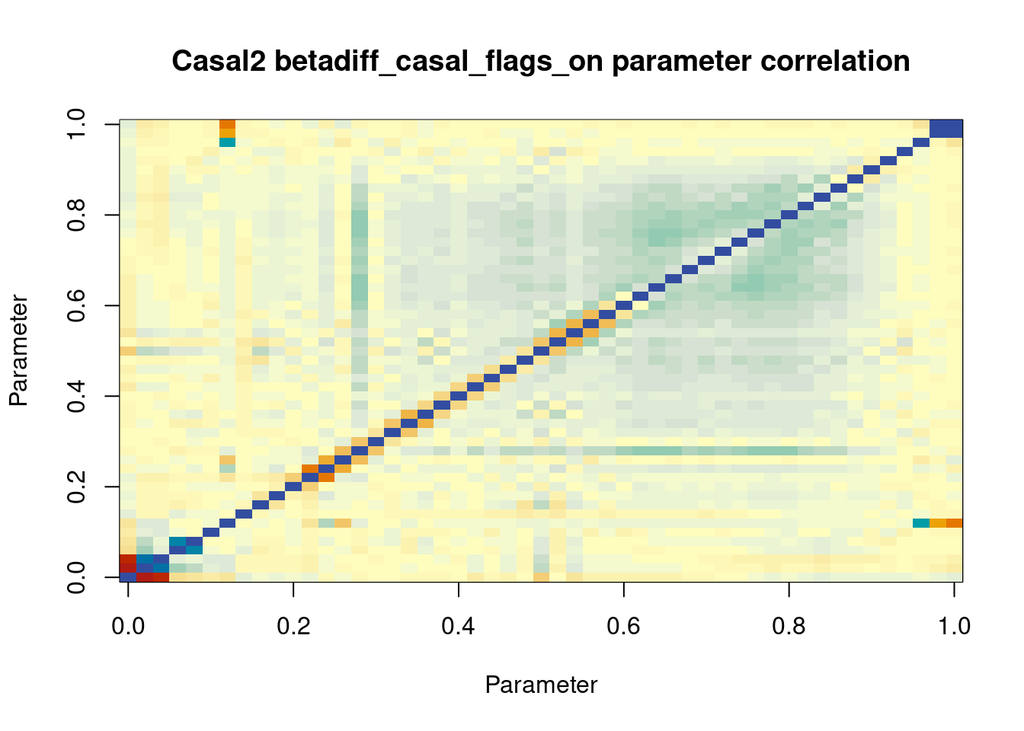

```
## [1] "Casal2 betadiff_casal_flags_on parameter correlation range (excluding 1.0): -0.934929639243574 0.971681216764646"
```

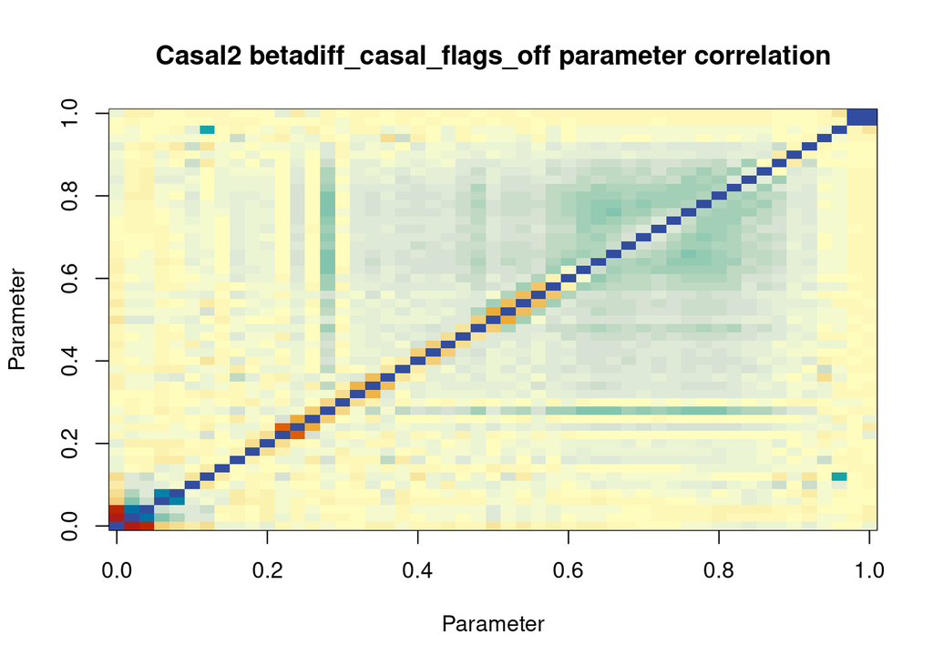

```
## [1] "Casal2 betadiff_casal_flags_off parameter correlation range (excluding 1.0): -0.938150664238124 0.971586289467802"
```

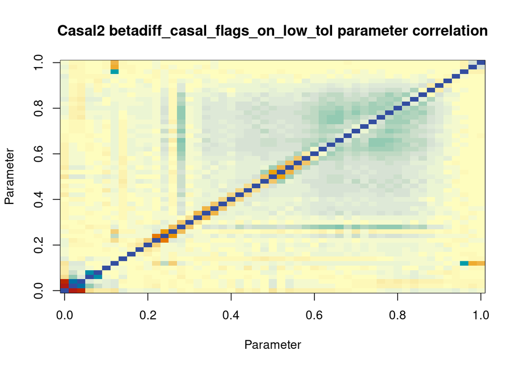

```
## [1] "Casal2 betadiff_casal_flags_on_low_tol parameter correlation range (excluding 1.0): -0.934544346046772 0.858143233305573"
```

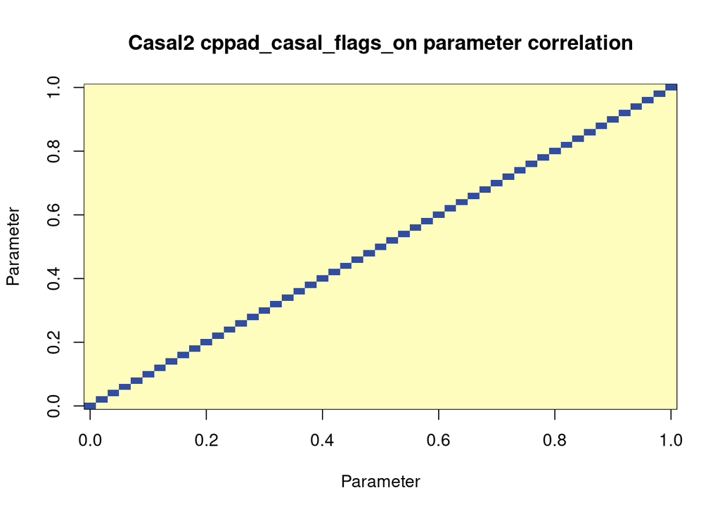

```
## [1] "Casal2 cppad_casal_flags_on parameter correlation range (excluding 1.0): 0 0"
```

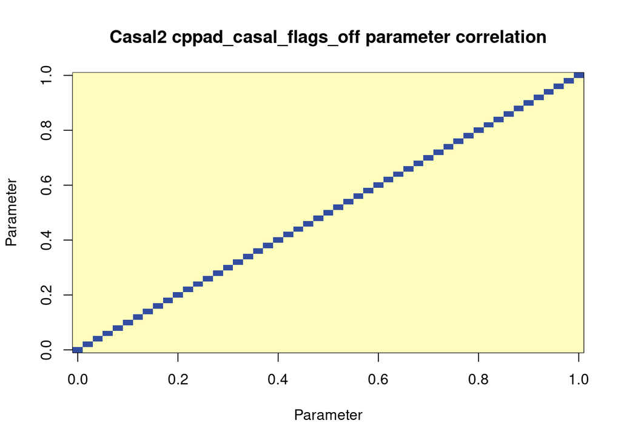

```
## [1] "Casal2 cppad_casal_flags_off parameter correlation range (excluding 1.0): 0 0"
```

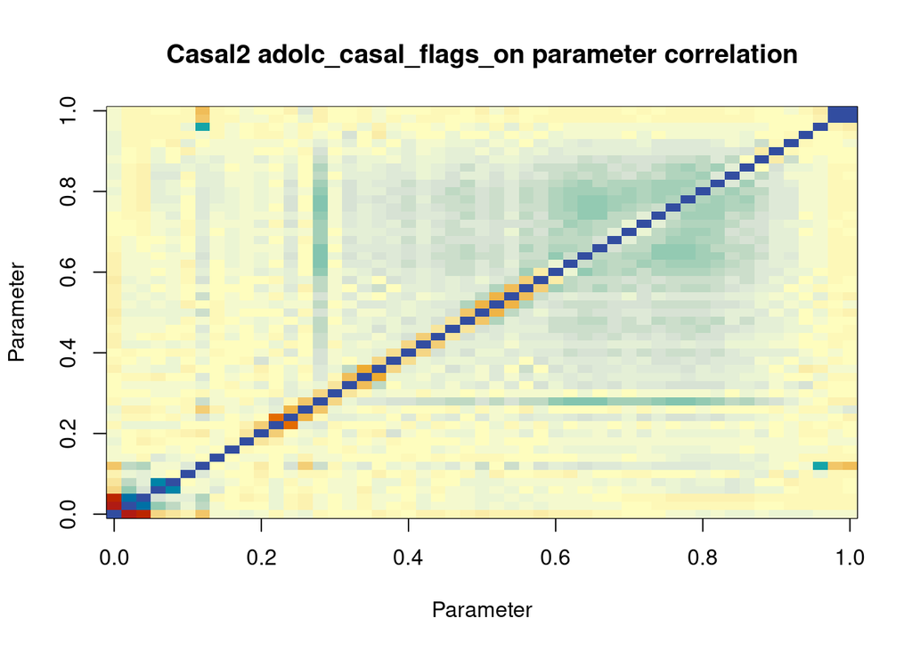

```
## [1] "Casal2 adolc_casal_flags_on parameter correlation range (excluding 1.0): -0.9335088237945 0.984686372572567"
```

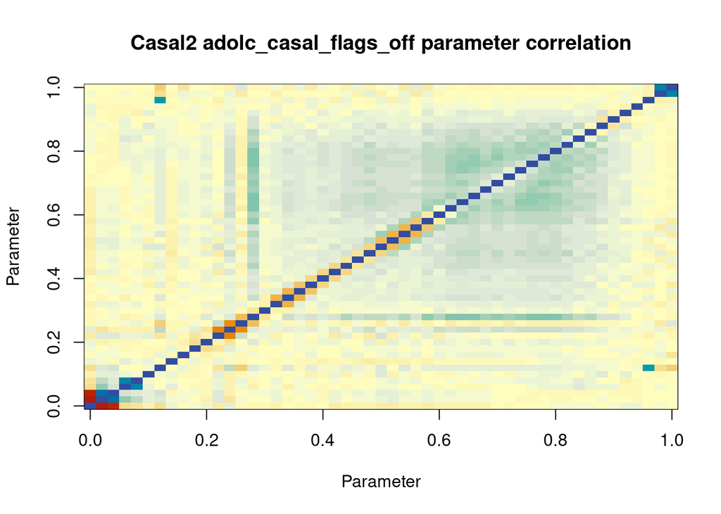

```
## [1] "Casal2 adolc_casal_flags_off parameter correlation range (excluding 1.0): -0.927654895860372 0.872116235193224"
```

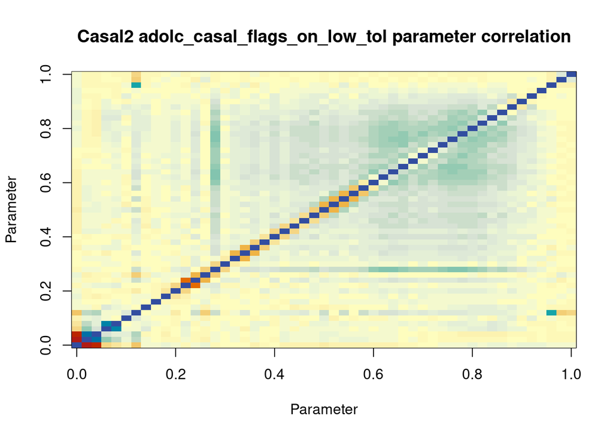

```
## [1] "Casal2 adolc_casal_flags_on_low_tol parameter correlation range (excluding 1.0): -0.931749296085358 0.870796154803461"
```

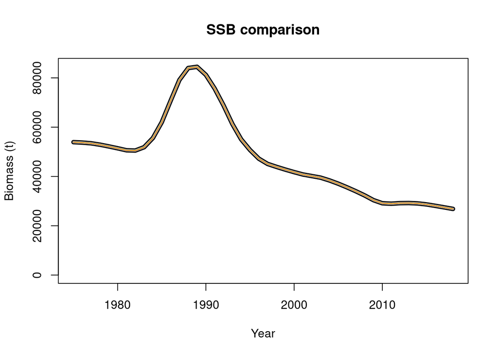

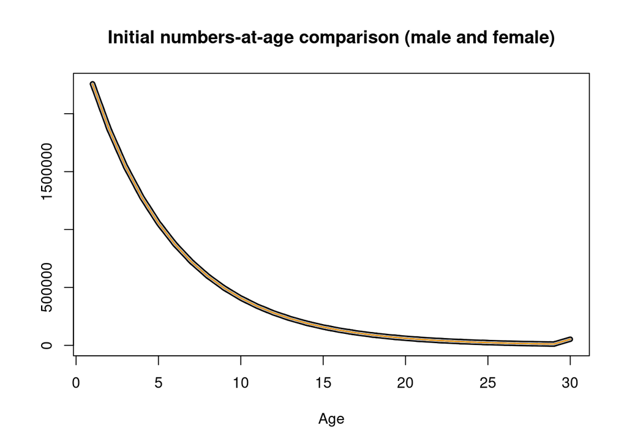

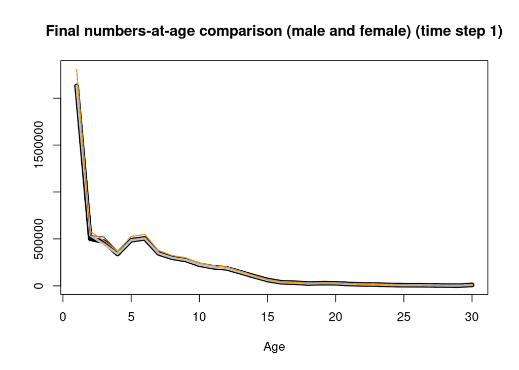

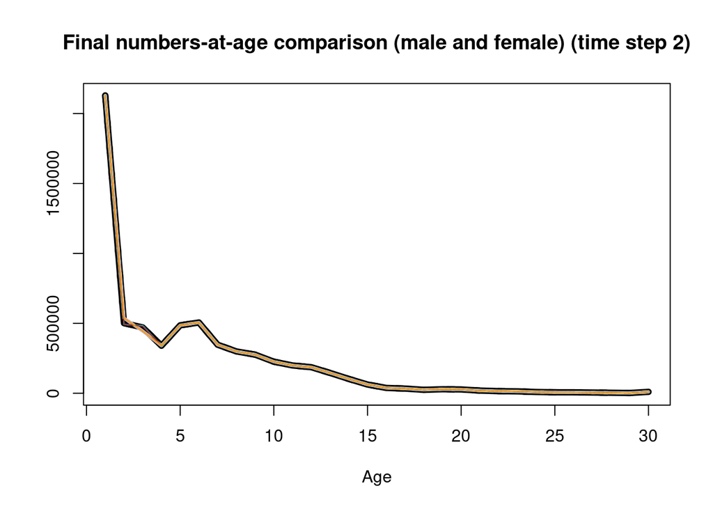

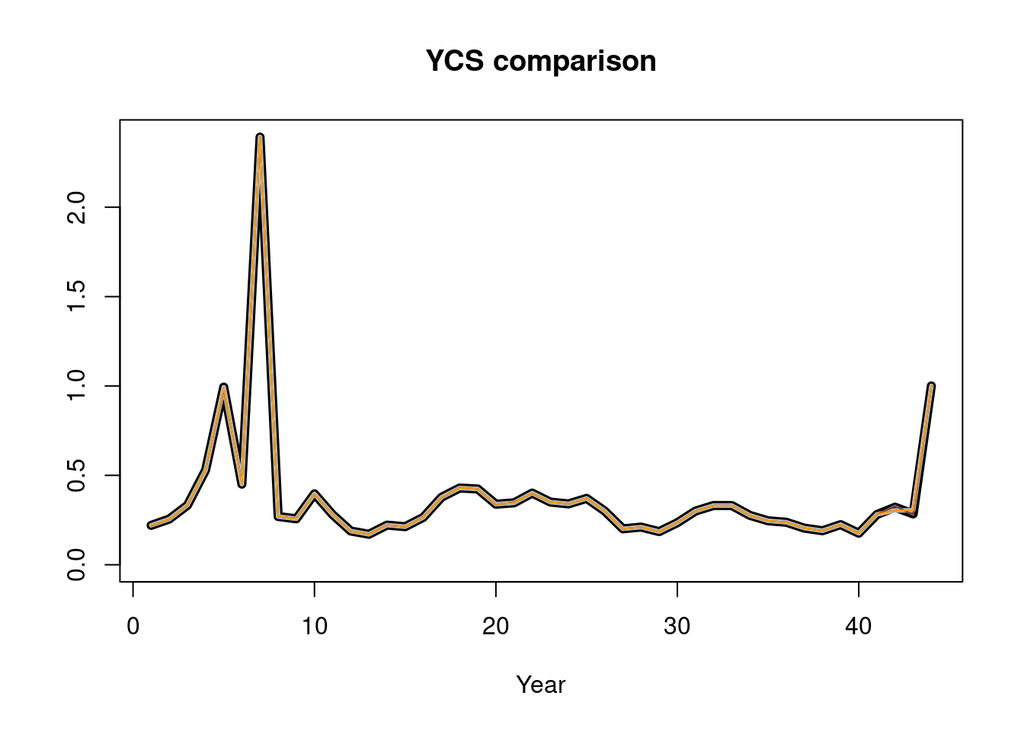

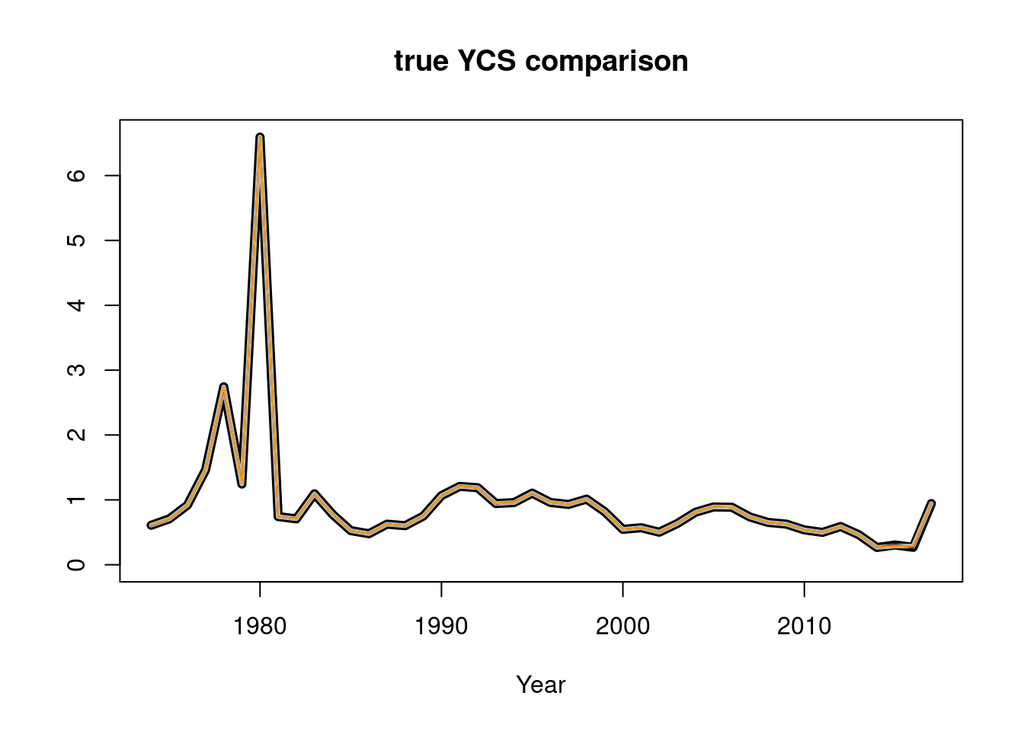

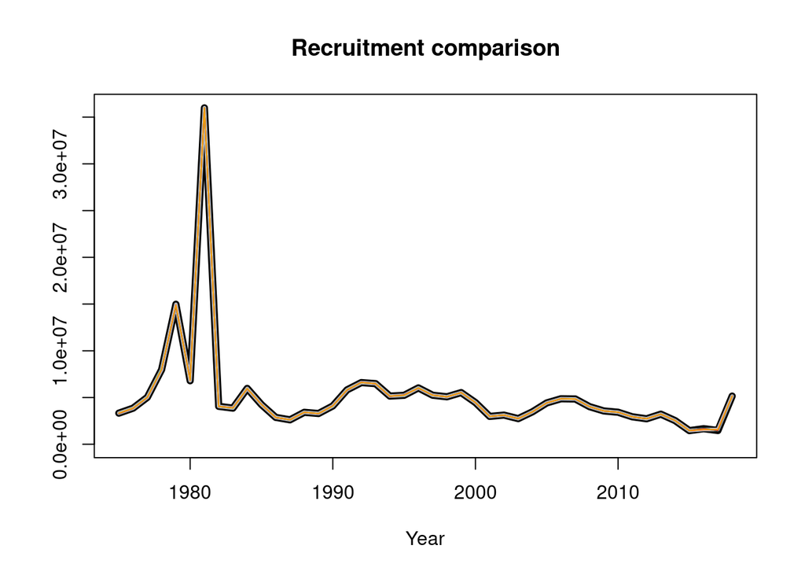

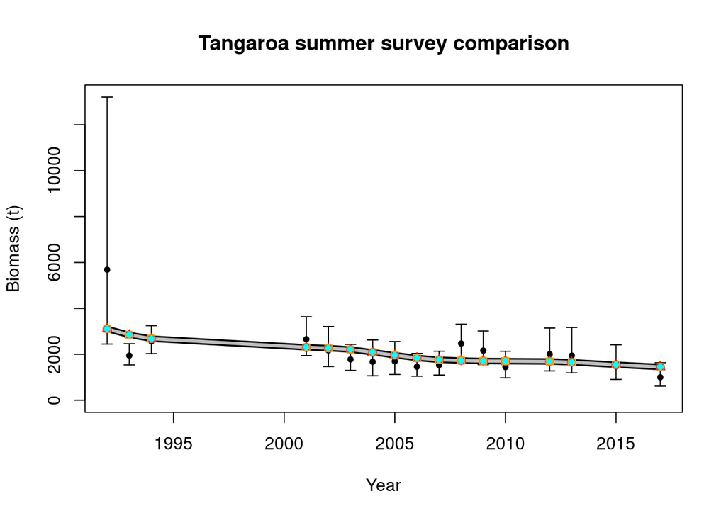

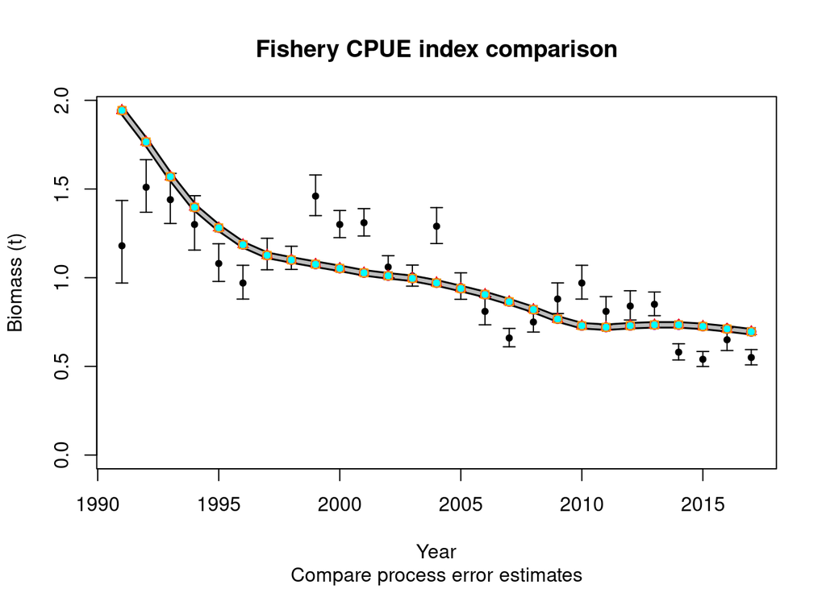

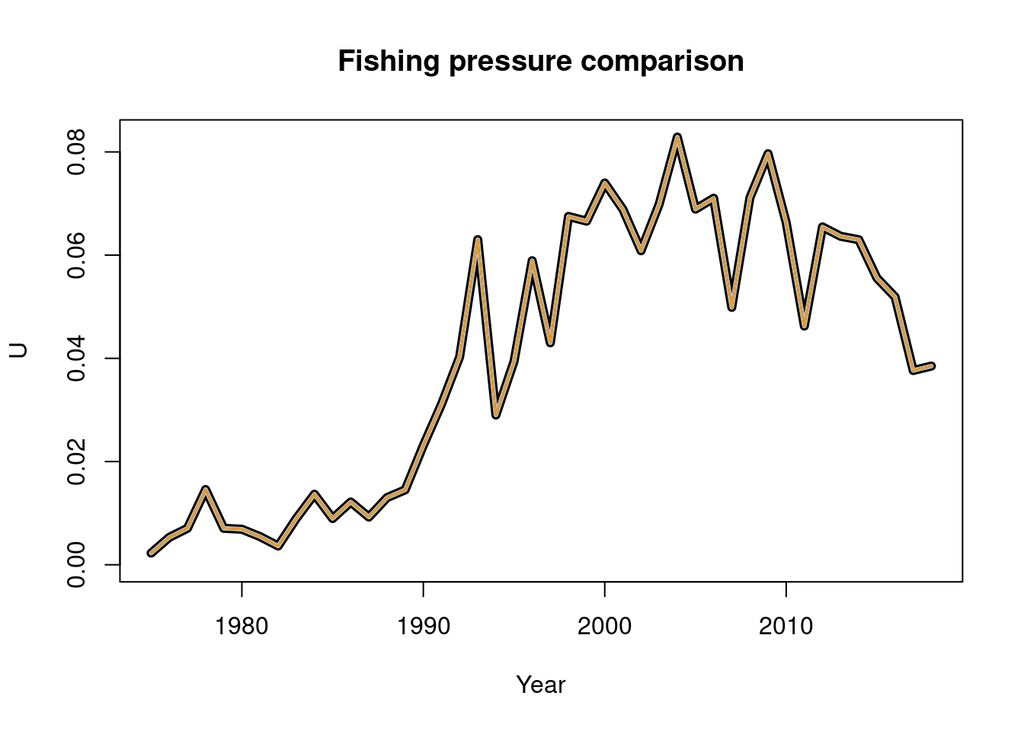

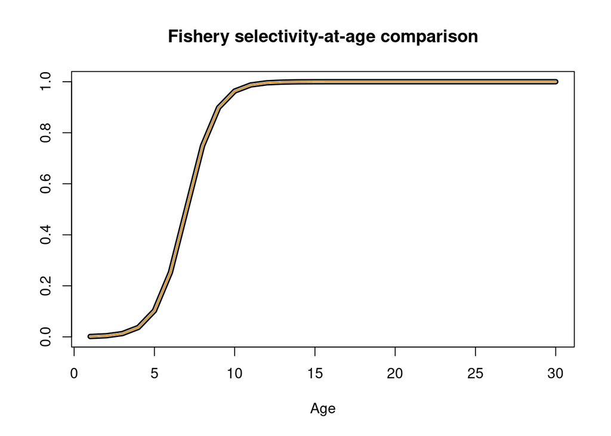

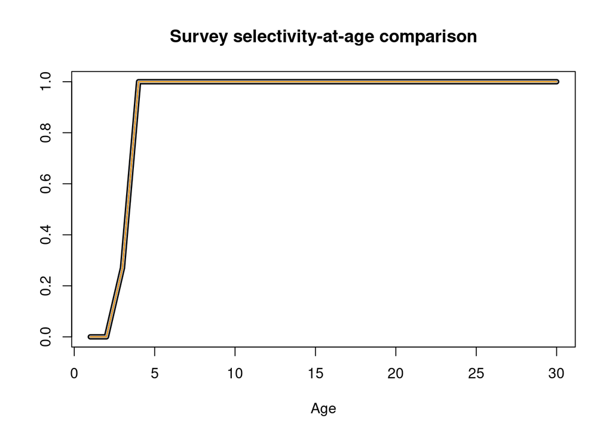